# Phase IIB Seamless Simulation Study Results

Suzanne Dufault

2022-03-14

## Simulation Study Results

### Conditions

#### Survival Conditions

| Setting | Regimen | Characteristics |
| --- | --- | --- |
| 1 | 2 | suboptimal, relapse rate is twice that of the control regimen |
|  | 3,4 | minimal, relapse rate is the same as the control regimen |
|  | 5 | desirable, relapse rate is half that of the control regimen |
| 2 | 2-5 | all are desirable, relapse rate is half that of the control regimen |
| 3 | 2-5 | all are minimal, relapse rate is the same as the control regimen |

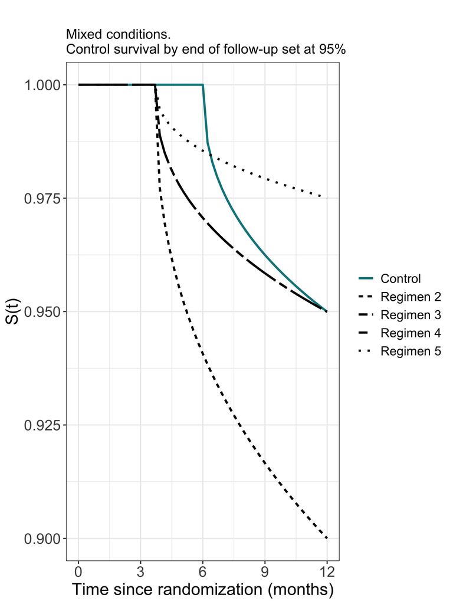

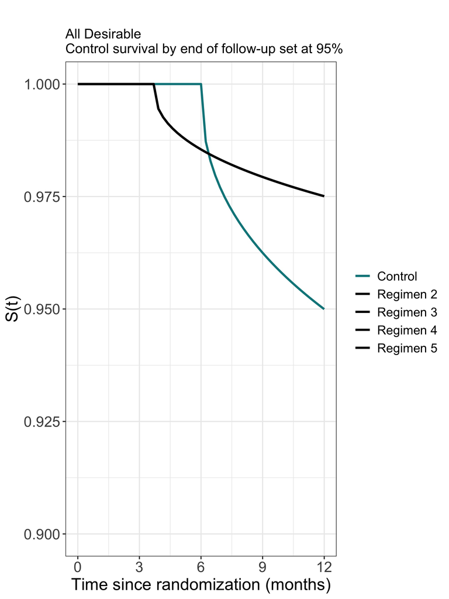

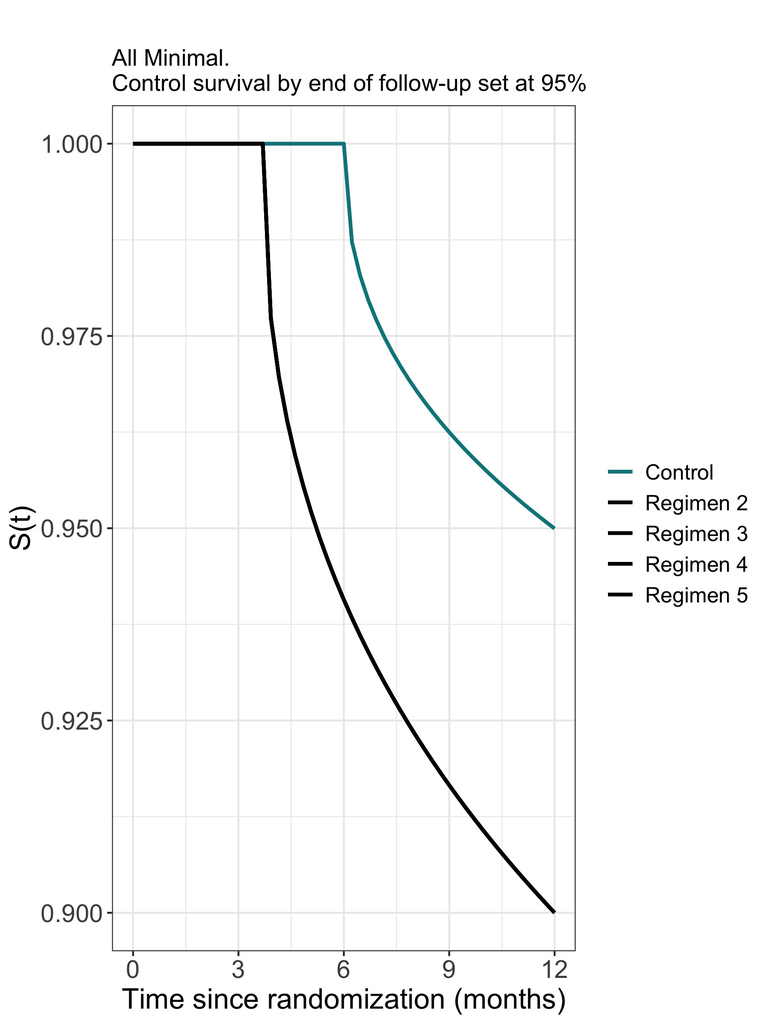

#### log10(TTP) conditions

- For each treatment arm, we will do a handful of hypothetical intervention effect sizes. These will be specified as percent change in slope *as compared to the control*.
  - $\{10\%,20\%,30\%,40\%\}$ (even relative increases by treatment arm)
  - $\{-10\%,10\%,35\%,40\%\}$ (two are near the control arm, two are better. Can we distinguish the best?)
  - $\{35\%, 37\%, 39\%, 41\%\}$

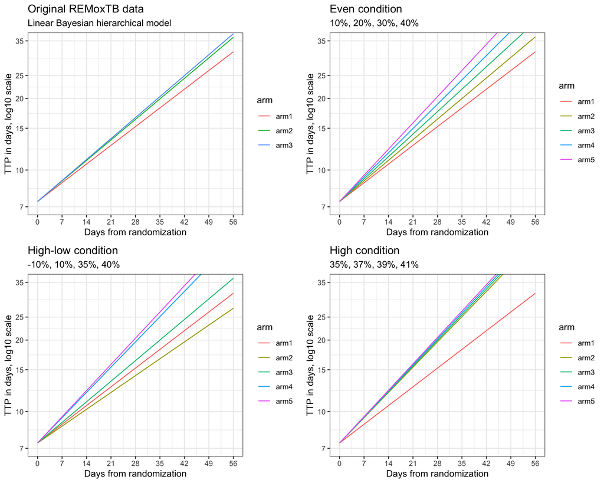

Visualization of conditions

### Simulation Results

#### Log10(TTP) Only

For the sake of this simulation study, we will consider dropping regimens that fail to meet the following criteria:

1. $\pi(\mu_k > \mu) \geq \alpha_1$. The probability that the slope for regimen $k$ is greater than the control slope must be at least $\alpha_1 = \{0.8, 0.9, 0.95\}$

##### 30 per regimen

| 30 per regimen Log10(TTP) Characteristics | P(Continues based off of log10(TTP)) P(better than control) > 0.8 and P(in top 2) > 0.8 | P(Continues based off of log10(TTP)) P(better than control) > 0.8 | P(Continues based off of log10(TTP)) P(better than control) > 0.9 | P(Continues based off of log10(TTP)) P(better than control) > 0.95 |
| --- | --- | --- | --- | --- |
| **Slopes are evenly distributed** |  |  |  |  |
| ref | 0.00 | 0.00 | 0.00 | 0.00 |
| 10% | 0.00 | 0.64 | 0.47 | 0.35 |
| 20% | 0.03 | 0.94 | 0.88 | 0.77 |
| 30% | 0.59 | 1.00 | 0.99 | 0.96 |
| 40% | 0.93 | 1.00 | 1.00 | 1.00 |
| **Slopes are clustered high** |  |  |  |  |
| ref | 0.00 | 0.00 | 0.00 | 0.00 |
| 35% | 0.08 | 1.00 | 1.00 | 0.99 |
| 37% | 0.15 | 1.00 | 1.00 | 1.00 |
| 39% | 0.22 | 1.00 | 1.00 | 1.00 |
| 41% | 0.36 | 1.00 | 1.00 | 1.00 |
| **Slopes are clustered high and low** |  |  |  |  |
| ref | 0.00 | 0.00 | 0.00 | 0.00 |
| -10% | 0.00 | 0.01 | 0.01 | 0.00 |
| 10% | 0.00 | 0.64 | 0.48 | 0.33 |
| 35% | 0.97 | 1.00 | 1.00 | 0.99 |
| 40% | 0.99 | 1.00 | 1.00 | 1.00 |

##### 40 per regimen

| 40 per regimen Log10(TTP) Characteristics | P(Continues based off of log10(TTP)) P(better than control) > 0.8 and P(in top 2) > 0.8 | P(Continues based off of log10(TTP)) P(better than control) > 0.8 | P(Continues based off of log10(TTP)) P(better than control) > 0.9 | P(Continues based off of log10(TTP)) P(better than control) > 0.95 |
| --- | --- | --- | --- | --- |
| **Slopes are evenly distributed** |  |  |  |  |
| ref | 0.00 | 0.00 | 0.00 | 0.00 |
| 10% | 0.00 | 0.67 | 0.51 | 0.37 |
| 20% | 0.02 | 0.96 | 0.90 | 0.84 |
| 30% | 0.66 | 1.00 | 1.00 | 0.99 |
| 40% | 0.98 | 1.00 | 1.00 | 1.00 |
| **Slopes are clustered high** |  |  |  |  |
| ref | 0.00 | 0.00 | 0.00 | 0.00 |
| 35% | 0.08 | 1.00 | 1.00 | 1.00 |
| 37% | 0.11 | 1.00 | 1.00 | 1.00 |
| 39% | 0.24 | 1.00 | 1.00 | 1.00 |
| 41% | 0.40 | 1.00 | 1.00 | 1.00 |
| **Slopes are clustered high and low** |  |  |  |  |
| ref | 0.00 | 0.00 | 0.00 | 0.00 |
| -10% | 0.00 | 0.02 | 0.00 | 0.00 |
| 10% | 0.00 | 0.67 | 0.50 | 0.38 |
| 35% | 0.99 | 1.00 | 1.00 | 1.00 |
| 40% | 1.00 | 1.00 | 1.00 | 1.00 |

##### 60 per regimen

[output not shown]

##### 80 per regimen

| 80 per regimen Log10(TTP) Characteristics | P(Continues based off of log10(TTP)) P(better than control) > 0.8 and P(in top 2) > 0.8 | P(Continues based off of log10(TTP)) P(better than control) > 0.8 | P(Continues based off of log10(TTP)) P(better than control) > 0.9 | P(Continues based off of log10(TTP)) P(better than control) > 0.95 |
| --- | --- | --- | --- | --- |
| **Slopes are evenly distributed** |  |  |  |  |
| ref | 0.00 | 0.00 | 0.00 | 0.00 |
| 10% | 0.00 | 0.82 | 0.72 | 0.59 |
| 20% | 0.01 | 1.00 | 1.00 | 1.00 |
| 30% | 0.87 | 1.00 | 1.00 | 1.00 |
| 40% | 1.00 | 1.00 | 1.00 | 1.00 |
| **Slopes are clustered high** |  |  |  |  |
| ref | 0.00 | 0.00 | 0.00 | 0.00 |
| 35% | 0.03 | 1.00 | 1.00 | 1.00 |
| 37% | 0.09 | 1.00 | 1.00 | 1.00 |
| 39% | 0.26 | 1.00 | 1.00 | 1.00 |
| 41% | 0.47 | 1.00 | 1.00 | 1.00 |
| **Slopes are clustered high and low** |  |  |  |  |
| ref | 0.00 | 0.00 | 0.00 | 0.00 |
| -10% | 0.00 | 0.00 | 0.00 | 0.00 |
| 10% | 0.00 | 0.86 | 0.77 | 0.60 |
| 35% | 1.00 | 1.00 | 1.00 | 1.00 |
| 40% | 1.00 | 1.00 | 1.00 | 1.00 |

##### Figures

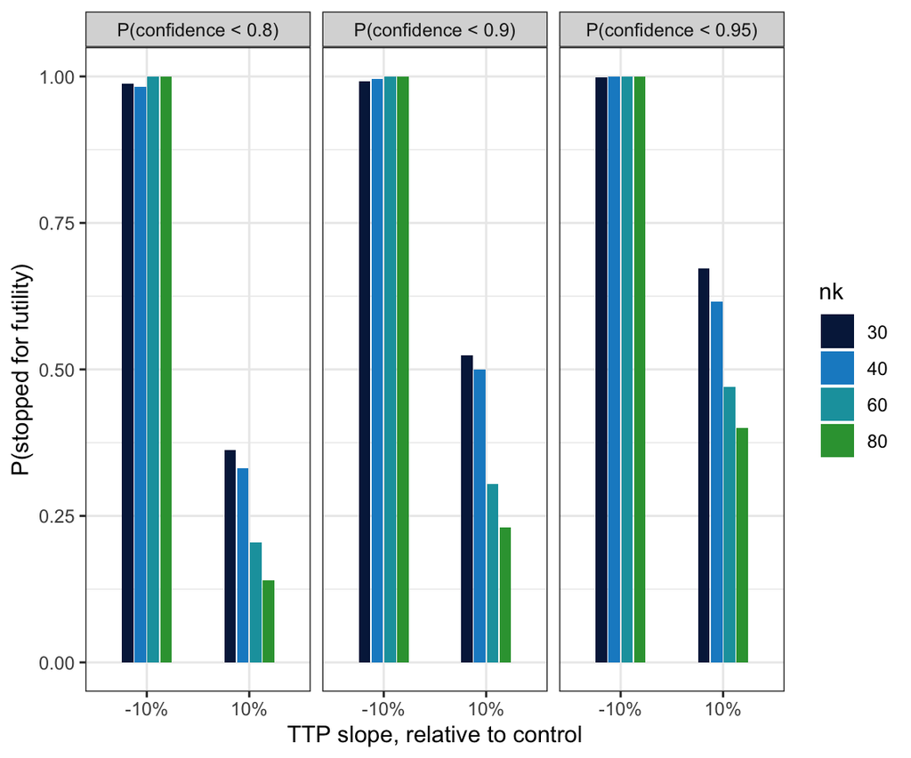

#### Relapse Only

##### Sub-optimal regimen

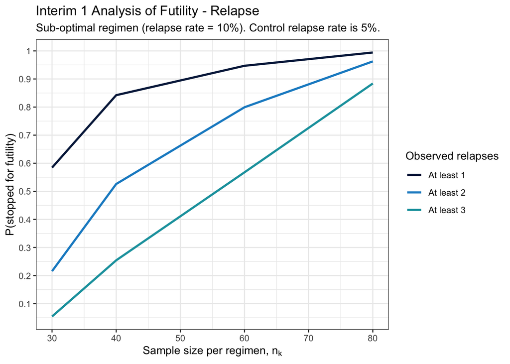

##### Minimal regimen

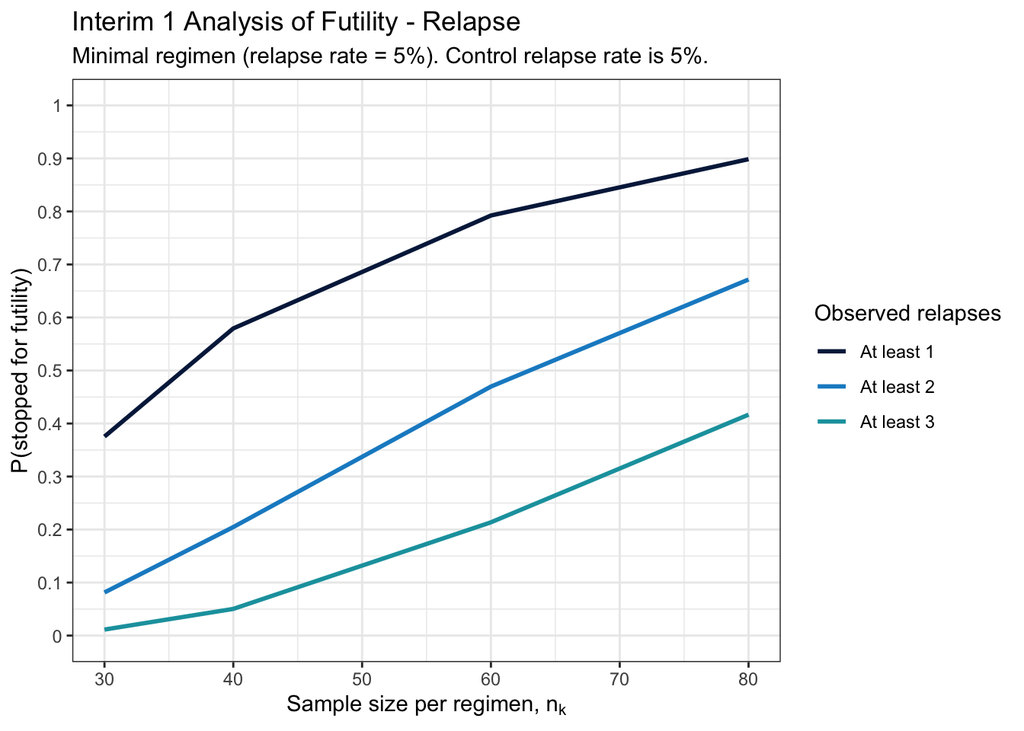

##### Desirable regimen

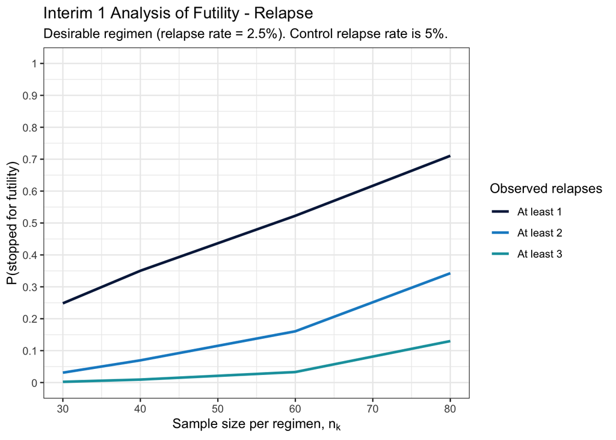

#### Log10(TTP) and Relapse

| nk | P(confidence < 0.8, >= 1 relapse) | P(confidence < 0.8, >= 2 relapse) | P(confidence < 0.8, >= 3 relapse) |
| --- | --- | --- | --- |
| **Even (TTP). Mixed relapse rates.** |  |  |  |
| **Control (relapse rate = 5%)** |  |  |  |
| 30 | 0.00 | 0.00 | 0.00 |
| 40 | 0.00 | 0.00 | 0.00 |
| 60 | 0.00 | 0.00 | 0.00 |
| 80 | 0.00 | 0.00 | 0.00 |
| **Regimen 1: suboptimal (TTP slope = 10%, relapse rate = 10%)** |  |  |  |
| 30 | 0.21 | 0.09 | 0.02 |
| 40 | 0.29 | 0.20 | 0.10 |
| 60 | 0.18 | 0.10 | 0.06 |
| 80 | 0.17 | 0.14 | 0.11 |
| **Regimen 2: minimal (TTP slope = 20%, relapse rate = 5%)** |  |  |  |
| 30 | 0.02 | 0.01 | 0.00 |
| 40 | 0.02 | 0.01 | 0.00 |
| 60 | 0.00 | 0.00 | 0.00 |
| 80 | 0.00 | 0.00 | 0.00 |
| **Regimen 3: minimal (TTP slope = 30%, relapse rate = 5%)** |  |  |  |
| 30 | 0.00 | 0.00 | 0.00 |
| 40 | 0.00 | 0.00 | 0.00 |
| 60 | 0.00 | 0.00 | 0.00 |
| 80 | 0.00 | 0.00 | 0.00 |
| **Regimen 4: desirable (TTP slope = 40%, relapse rate = 2.5%)** |  |  |  |
| 30 | 0.00 | 0.00 | 0.00 |
| 40 | 0.00 | 0.00 | 0.00 |
| 60 | 0.00 | 0.00 | 0.00 |
| 80 | 0.00 | 0.00 | 0.00 |
| **High (TTP). Mixed relapse rates.** |  |  |  |
| **Control (relapse rate = 5%)** |  |  |  |
| 30 | 0.00 | 0.00 | 0.00 |
| 40 | 0.00 | 0.00 | 0.00 |
| 60 | 0.00 | 0.00 | 0.00 |
| 80 | 0.00 | 0.00 | 0.00 |
| **Regimen 1: suboptimal (TTP slope = 35%, relapse rate = 10%)** |  |  |  |
| 30 | 0.00 | 0.00 | 0.00 |
| 40 | 0.00 | 0.00 | 0.00 |
| 60 | 0.00 | 0.00 | 0.00 |
| 80 | 0.00 | 0.00 | 0.00 |
| **Regimen 2: minimal (TTP slope = 37%, relapse rate = 5%)** |  |  |  |
| 30 | 0.00 | 0.00 | 0.00 |
| 40 | 0.00 | 0.00 | 0.00 |
| 60 | 0.00 | 0.00 | 0.00 |
| 80 | 0.00 | 0.00 | 0.00 |
| **Regimen 3: minimal (TTP slope = 39%, relapse rate = 5%)** |  |  |  |
| 30 | 0.00 | 0.00 | 0.00 |
| 40 | 0.00 | 0.00 | 0.00 |
| 60 | 0.00 | 0.00 | 0.00 |
| 80 | 0.00 | 0.00 | 0.00 |
| **Regimen 4: desirable (TTP slope = 41%, relapse rate = 2.5%)** |  |  |  |
| 30 | 0.00 | 0.00 | 0.00 |
| 40 | 0.00 | 0.00 | 0.00 |
| 60 | 0.00 | 0.00 | 0.00 |
| 80 | 0.00 | 0.00 | 0.00 |
| **High-low (TTP)** |  |  |  |
| **Control (relapse rate = 5%)** |  |  |  |
| 30 | 0.00 | 0.00 | 0.00 |
| 40 | 0.00 | 0.00 | 0.00 |
| 60 | 0.00 | 0.00 | 0.00 |
| 80 | 0.00 | 0.00 | 0.00 |
| **Regimen 1: suboptimal (TTP slope = -10%, relapse rate = 10%)** |  |  |  |
| 30 | 0.40 | 0.11 | 0.03 |
| 40 | 0.74 | 0.34 | 0.13 |
| 60 | 0.77 | 0.46 | 0.22 |
| 80 | 0.97 | 0.85 | 0.60 |
| **Regimen 2: minimal (TTP slope = 10%, relapse rate = 5%)** |  |  |  |
| 30 | 0.08 | 0.01 | 0.00 |
| 40 | 0.15 | 0.03 | 0.01 |
| 60 | 0.08 | 0.03 | 0.01 |
| 80 | 0.09 | 0.04 | 0.02 |
| **Regimen 3: minimal (TTP slope = 35%, relapse rate = 5%)** |  |  |  |
| 30 | 0.00 | 0.00 | 0.00 |
| 40 | 0.00 | 0.00 | 0.00 |
| 60 | 0.00 | 0.00 | 0.00 |
| 80 | 0.00 | 0.00 | 0.00 |
| **Regimen 4: desirable (TTP slope = 40%, relapse rate = 2.5%)** |  |  |  |
| 30 | 0.00 | 0.00 | 0.00 |
| 40 | 0.00 | 0.00 | 0.00 |
| 60 | 0.00 | 0.00 | 0.00 |
| 80 | 0.00 | 0.00 | 0.00 |

### Single Analysis

#### Full data

interim 1

| regimen | No. patients | No. relapses | Median FU (weeks) | Min FU (weeks) | Max FU (weeks) | Median percent change in TTP slope | CI.l on percent change in TTP slope | CI.u on percent change in TTP slope | Confidence regimen has steeper slope than control | Confidence regimen is best | Confidence regimen is one of top two best |
| --- | --- | --- | --- | --- | --- | --- | --- | --- | --- | --- | --- |
| 1 | 36 | 1 | 20.14 | 13.29 | 28.86 |  |  |  |  | 0.00 | 0 |
| 2 | 30 | 1 | 19.50 | 13.00 | 29.86 | 0.06 | -0.07 | 0.20 | 0.79 | 0.00 | 0 |
| 3 | 31 | 3 | 22.86 | 15.86 | 29.86 | 0.08 | -0.05 | 0.23 | 0.87 | 0.00 | 0 |
| 4 | 31 | 2 | 20.86 | 13.29 | 29.86 | 0.29 | 0.13 | 0.46 | 1.00 | 0.22 | 1 |
| 5 | 34 | 1 | 21.86 | 13.00 | 30.00 | 0.35 | 0.20 | 0.54 | 1.00 | 0.78 | 1 |

interim 2

| regimen | No. patients | No. relapses | Median FU (weeks) | Min FU (weeks) | Max FU (weeks) | Median percent change in TTP slope | CI.l on percent change in TTP slope | CI.u on percent change in TTP slope | Confidence regimen has steeper slope than control | Confidence regimen is best | Confidence regimen is one of top two best |
| --- | --- | --- | --- | --- | --- | --- | --- | --- | --- | --- | --- |
| 1 | 60 | 1 | 28.36 | 13.00 | 41.43 |  |  |  |  | 0.00 | 0 |
| 2 | 60 | 2 | 25.36 | 13.14 | 42.43 | 0.10 | -0.01 | 0.21 | 0.96 | 0.00 | 0 |
| 3 | 60 | 4 | 28.86 | 13.43 | 42.43 | 0.16 | 0.06 | 0.29 | 1.00 | 0.00 | 0 |
| 4 | 60 | 3 | 26.07 | 13.14 | 42.43 | 0.34 | 0.21 | 0.48 | 1.00 | 0.15 | 1 |
| 5 | 60 | 1 | 28.21 | 13.43 | 42.57 | 0.40 | 0.27 | 0.55 | 1.00 | 0.85 | 1 |

```
## [1] 81.85714
```

#### Interim 1

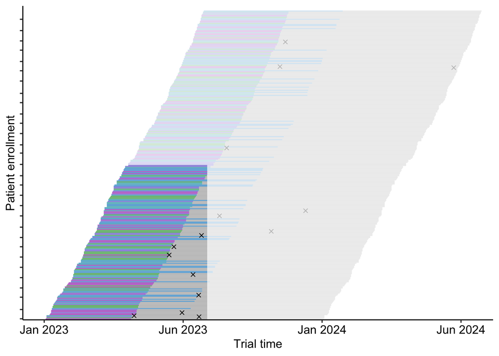

Number of relapses observed per regimen by the first interim analysis.

| regimen | No. relapses |
| --- | --- |
| 1 | 1 |
| 2 | 1 |
| 3 | 3 |
| 4 | 2 |
| 5 | 1 |

|  | Estimate | Est.Error | l-95% CI | u-95% CI | Rhat | Bulk_ESS | Tail_ESS |
| --- | --- | --- | --- | --- | --- | --- | --- |
| Intercept | 0.849 | 0.015 | 0.821 | 0.878 | 1.001 | 2694.035 | 2955.523 |
| week | 0.087 | 0.004 | 0.078 | 0.095 | 1.000 | 2645.522 | 3223.582 |
| week:regimen2 | 0.005 | 0.006 | -0.006 | 0.016 | 1.001 | 2815.309 | 2929.592 |
| week:regimen3 | 0.007 | 0.006 | -0.005 | 0.019 | 1.000 | 2988.644 | 3262.853 |
| week:regimen4 | 0.025 | 0.007 | 0.012 | 0.038 | 1.001 | 2811.111 | 3157.383 |
| week:regimen5 | 0.030 | 0.007 | 0.018 | 0.044 | 1.001 | 2800.426 | 3138.729 |

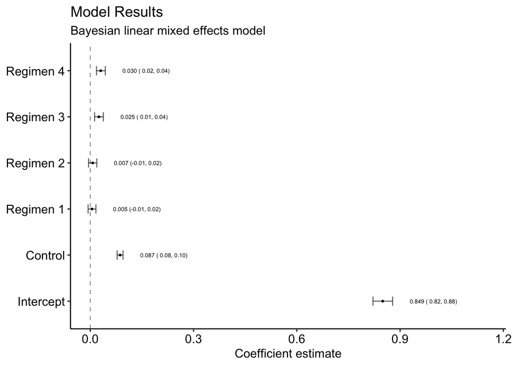

| regimen | prop_best | bestarm |
| --- | --- | --- |
| 1 | 0.0000 | regimen1 |
| 2 | 0.0000 | regimen2 |
| 3 | 0.0000 | regimen3 |
| 4 | 0.2222 | regimen4 |
| 5 | 0.7778 | regimen5 |

How confident are we that our chosen subset contains the best regimen?

```
##   perc.confidence subset.size
## 1          0.8465           1
## 2          1.0000           2
## 3          1.0000           3
## 4          1.0000           4
```

How certain can we be that the rate of change in log10(TTP) for any regimen is different from the rate of change for the control?

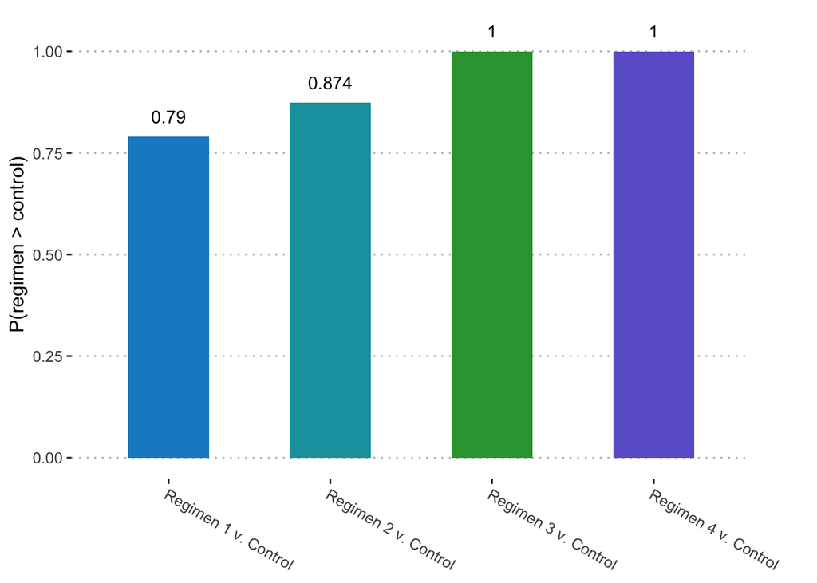

[figure not shown]

#### Interim 2

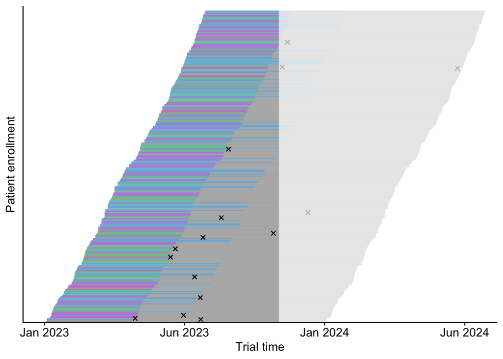

#### Final Analysis

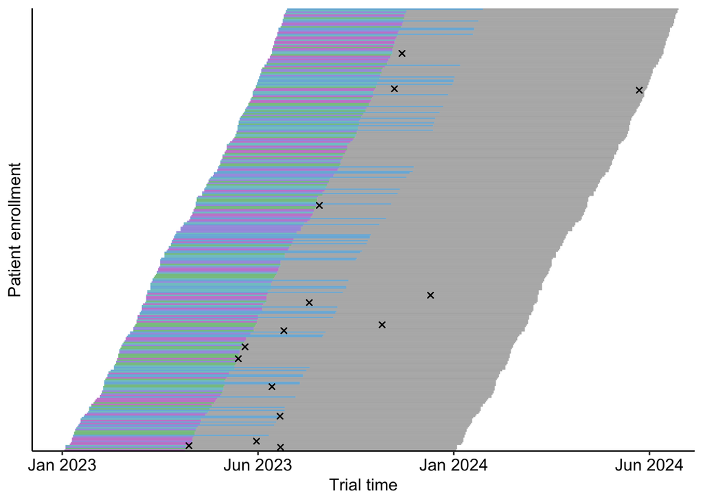